# ttests rush contributions

Lydia White

2022-04-29

calculation of consumer contributions to stability and significance testing. Creates figures 2 & 3 from manuscript, and corresponding t-tests.

```r
library(readr)
data <- read_csv(here::here("data","RUSH_MACRO_Concise.csv"))
```

```r
library(tidyverse)
library(vegan)
library(lsmeans)
library(emmeans)
library(car)
library(lme4)
library(lmerTest)
library(ggh4x)
library(patchwork)
library(ggpubr)
library(rstatix)
```

# Intact communities

First we can explore community responses to stressors. Can explore intact communities immediately after distubance period (so month 12)

Treatments: A Algae B Algae & Grazers C Algae, Grazers & Whelks D Uncaged control plot

N0 No Nutrients N1 Enriched with Nutrients S0 No Sediment S1 Sediment added

Functional responses are based on total percentage cover of all algal species as a proxy for biomass. Total percentage cover values often exceeded 100% due to the multi-layered nature of macroalgal communities.

```r
data$Plot <- gsub("24\\*", "100", data$Plot)

cols <-data %>% select(Fuc_Ves:Hilden) # columns of interest i.e. species

functional<- data%>%
  mutate_if(is.numeric, ~replace(., is.na(.), 0))%>%
   mutate(sum = rowSums(cols)) %>%
   select(Time:Treatment,sum) %>%
    filter(Time > 5 ) %>%
    rename(TAC = `sum`)
```

We compare total algal cover for disturbance treatments.

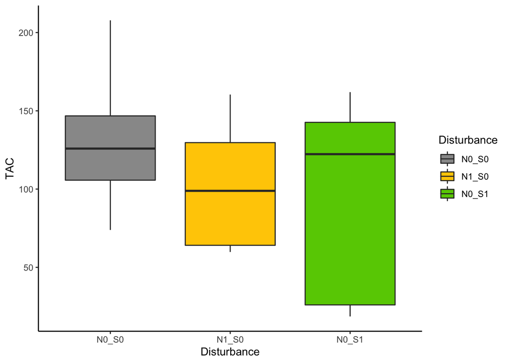

```r
intact<- functional%>%separate(Treatment, c("Diversity", "Nutrients","Sediment"), remove = F)%>%
  unite(Disturbance,c("Nutrients","Sediment"),sep="_")%>%
  filter(Disturbance != "N1_S1")%>%
  filter(Time == 12 & Diversity == 'C')%>%
  mutate(Disturbance = as_factor(Disturbance))


ggplot(intact, aes(x=Disturbance, y=TAC))+
  geom_boxplot(aes(fill = Disturbance))+
  scale_fill_manual(values = c("#999999", "#FFCC00","#66CC00"))+
  theme_classic()
```

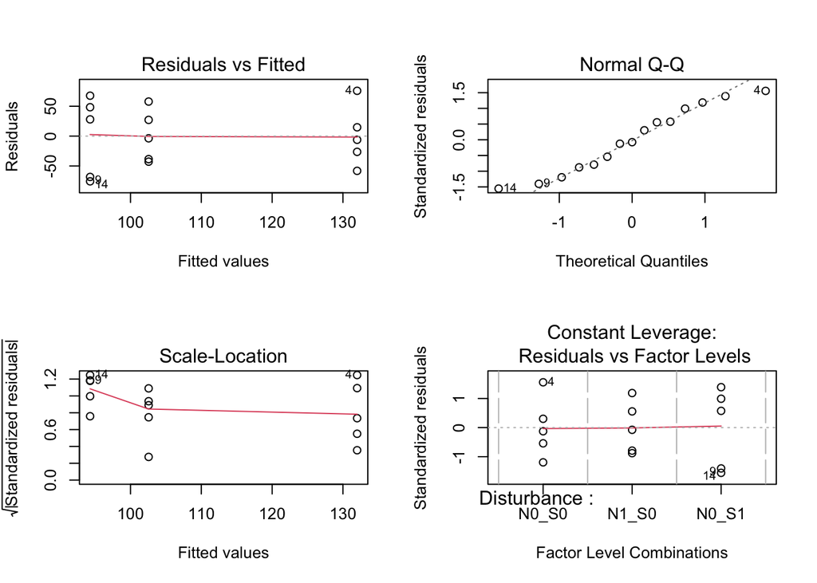

```r
mod1<-lm(TAC~Disturbance, data = intact)

par(mfrow=c(2,2))
plot(mod1)
```

```r
par(mfrow=c(1,1))
anova(mod1)
```

```
## Analysis of Variance Table
##
## Response: TAC
##             Df Sum Sq Mean Sq F value Pr(>F)
## Disturbance  2   3927  1963.4  0.6626 0.5334
## Residuals   12  35561  2963.4
```

# Functional stability

Functional stability is calculated using total percentage cover of all algal species as a proxy for biomass. Total percentage cover values often exceeded 100% due to the multi-layered nature of macroalgal communities. To calculate stability values we are only interested in data following the perturbation, month 6 onwards.

## Stability metrics

We calculate 4 different metrics using total algal cover data from the time period following the perturbations (months 6 to 15).

### Temporal variability

Temporal variability is calculated as the coefficient of variance (CV; that is, standard deviation divided by the mean) of total algal cover in each experimental plot over time during the pertubation phase. Detrended to remove potentially confounding effects of biomass change over the duration of the experiment.

We run linear models on total algal cover in each plot over time and use the residuals from these models to calculate the CV

```r
tmp<-functional%>%
  select(Diversity,Plot,Time, TAC,Treatment)%>%
  filter(Time < 13)

tmp = split(tmp,tmp$Plot)

resids<-lapply(names(tmp),function(X){
  Y <- tmp[[X]]
  A <-residuals(lm(TAC~Time, data = Y))
  B <-Y$Diversity
  B2<-Y$Treatment
  C <-Y$Time
  D <-Y$TAC
  E <-sd(A)/mean(D)
  data_frame(Plot=X,Residuals=A, Diversity=B, Treatment = B2, Time=C, TAC =D, Temp.Var=E)
})

Temp_Var<-lapply(resids,function(X){
  X[1,]
}) %>%
  Reduce("rbind",.)%>%
  select(Plot,Diversity,Treatment,Temp.Var)
```

### Spatial variability

Spatial variability was calculated as the CV of total algal cover among experimental plots within each stressor vs. consumer loss treatment combination on each census during the pertubation phase. Detrended to remove potentially confounding effects of biomass change over the duration of the experiment.

So we use the residuals from the previous linear regressions. This time we divide SD of the residuals across plots for each time period by the mean total algal cover.

```r
Spatial_Var<- Reduce("rbind",resids)%>%
  select(Time,Plot,Diversity,Treatment, Residuals,TAC)%>%
  group_by(Time, Diversity, Treatment) %>%
  summarise(Spa.Var = sd(Residuals)/mean(TAC))
```

### Resistance

Resistance and resilience are associated with a perturbation, they can only be calculated by comparing algal cover in perturbed treatments to cover within unperturbed treatments.

Resistance was defined as the log response ratio (LRR) of total algal cover in a perturbed relative to unperturbed plot at th end of the perturbation phase. We calculated the LRR of total algal cover in each perturbed plot relative to the mean cover in unperturbed plots for the corresponding consumer loss treatment, for the final time point (month 12) during the perturbation phase (months 6 - 12).

```r
mean_cover<-functional %>%
   filter (Time == 12 & Nutrients == 'N0' & Sediment == 'S0') %>%
  group_by(Diversity, Time)%>%
  summarise(meanTAC = mean(TAC))

cover<-functional %>%
   filter (Time == 12 ) %>%
  select(Diversity,Treatment,Time,Plot,TAC)


LRR_Resist<-left_join(cover,mean_cover)%>%
  mutate(LRR_TAC = log(TAC/meanTAC))%>%
  filter(Treatment != 'A_N0_S0' & Treatment != 'B_N0_S0' & Treatment != 'C_N0_S0' &   Treatment != 'D_N0_S0')%>%
  rename(Resist = LRR_TAC)%>%
 select(Plot, Diversity, Treatment, Resist)
```

### Resilience

Resilience is the slope of linear regression of the log response ratio over time from the end of the pertubation phase to the end of the experiment. Calculating the log difference is equivalent to calculating the rate of relative return, rather than the absolute rate, rendering resilience at least conceptually independent from resistance. So we run a lm on LRR in between months 12 and months 15.

```r
mean_cover<-functional %>%
   filter (Time > 11 & Nutrients == 'N0' & Sediment == 'S0') %>%
  group_by(Diversity, Time)%>%
  summarise(meanTAC = mean(TAC))

cover<-functional %>%
   filter (Time > 11) %>%
  select(Diversity,Treatment,Time,Plot,TAC)

LRR<-left_join(cover,mean_cover)%>%
  mutate(LRR_TAC = log(TAC/meanTAC))

Resil<-lapply(1:nrow(LRR_Resist),function(i){
  X = LRR_Resist[i,]
  tmp =  filter(LRR,Plot == X$Plot)
  tmp<-lm(LRR_TAC~Time,data = tmp)
  coef2 = tmp$coefficients["Time"]
  data_frame(Plot=X$Plot,Resilience=coef2)
})%>% Reduce("rbind",.)
```

We can compile all the stabilty measures. For the few cases where perturbations increased biomass and, therefore, resulted in a positive resistance value, resilience was then multiplied by -1. We can plot the raw stabilty measures as boxplots.

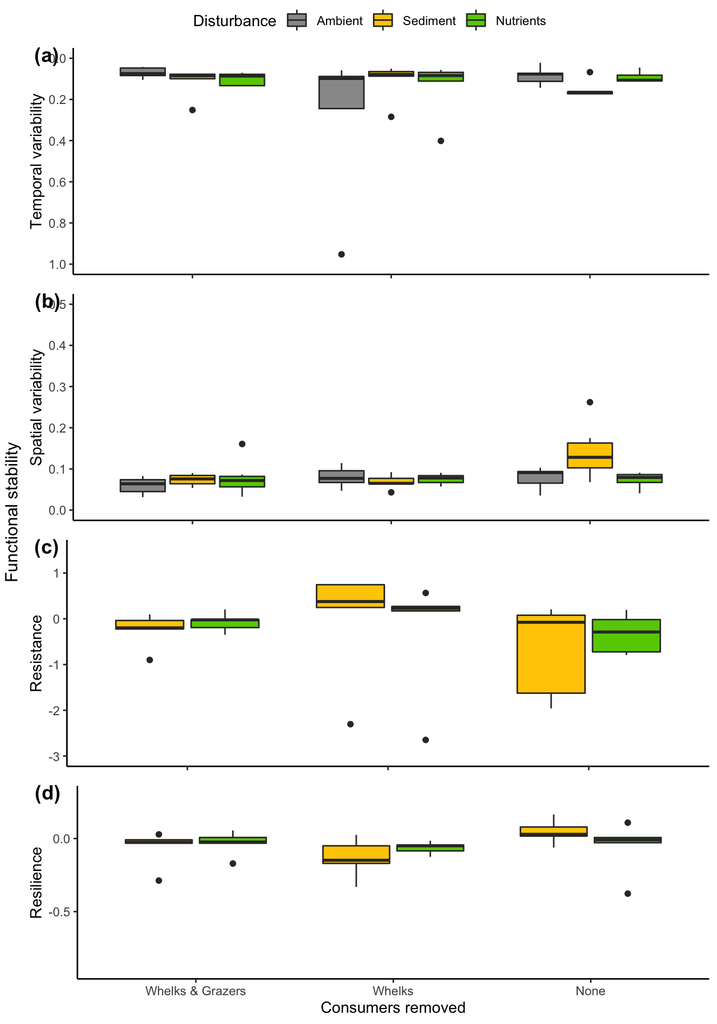

```r
Stability_metrics<-left_join(LRR_Resist,Resil)%>%
  mutate(Resilience = ifelse(Resist >0, Resilience*-1, Resilience))%>%
  select(Plot,Diversity,Treatment,Resist,Resilience)%>%
  gather(key = metric, value = value, -Diversity, -Treatment, -Plot)%>%
  rename(rep = Plot)

Temp_Var<-Temp_Var%>%
gather(key = metric, value = value,  -Diversity, -Treatment, -Plot)%>%
rename(rep = Plot)

Spatial_Var<-Spatial_Var%>%
gather(key = metric, value = value,  -Diversity, -Treatment, -Time)%>%
rename(rep = Time )%>%
ungroup(rep)%>%
mutate(rep = as.factor(rep))

x <-rbind(Stability_metrics, Temp_Var,data.frame(Spatial_Var))%>%
  filter(Diversity != "D")%>%
  separate(Treatment, c("Diversity", "Nutrients","Sediment"), remove = F)%>%
  unite(Disturbance,c("Nutrients","Sediment"),sep="_")%>%
  filter(Disturbance != "N1_S1")%>%
  mutate(metric = factor(metric,levels = c( "Temp.Var", "Spa.Var", "Resist", "Resilience")))%>%
  mutate(Disturbance = plyr::mapvalues(Disturbance, from = c("N0_S0","N0_S1","N1_S0"), to = c("Ambient","Sediment","Nutrients")))%>%
  mutate(Disturbance = factor(Disturbance,levels = c("Ambient", "Sediment","Nutrients")))%>%
  mutate(Diversity = plyr::mapvalues(Diversity, from = c("A","B","C"), to = c("Whelks & Grazers","Whelks","None")))%>%
  mutate(Diversity = factor(Diversity,levels = c("Whelks & Grazers","Whelks","None")))

A <-ggplot(data = subset(x,
              metric == "Temp.Var"), aes(x=Diversity, y=value)) +
  geom_boxplot(aes(fill = Disturbance)) +
  theme_classic()+
  scale_y_reverse(limits = c(1, 0), breaks = seq( 0,1, by = 0.2))+
  ylab("Temporal variability") +
  scale_fill_manual(values = c("#999999", "#FFCC00","#66CC00"))

C<-ggplot(data = subset(x,
              metric == "Spa.Var"), aes(x=Diversity, y=value)) +
  geom_boxplot(aes(fill = Disturbance)) +
  theme_classic()+
  ylab("Spatial variability") +
  ylim(0,0.5) +
  scale_fill_manual(values = c("#999999", "#FFCC00","#66CC00"))

E<-ggplot(data = subset(x,
              metric == "Resist"), aes(x=Diversity, y=value)) +
  geom_boxplot(aes(fill = Disturbance)) +
  theme_classic()+
  ylab("Resistance") +
  ylim(-3,1.5) +
  scale_fill_manual(values = c("#FFCC00","#66CC00"))

G<-ggplot(data = subset(x,
              metric == "Resilience"), aes(x=Diversity, y=value)) +
  geom_boxplot(aes(fill = Disturbance)) +
  theme_classic()+
  ylab("Resilience") +
  xlab("Consumers removed") +
  ylim(-0.9,0.3) +
  scale_fill_manual(values = c("#FFCC00","#66CC00"))

P_Func <- ggarrange(A + rremove("xlab") + rremove("x.text"), C + rremove("xlab") + rremove("x.text"),E + rremove("xlab") + rremove("x.text"), G, heights = c(1, 1,1,1), ncol = 1, nrow = 4,common.legend = T, labels = c("(a)", "(b)", "(c)", "(d)"))

annotate_figure(P_Func, left = text_grob("Functional stability", rot = 90))
```

## Consumer contributions

Contributions of grazers and predators to algal stability were then quantified as the inverse of the calculated stability metrics, that is, a strong destabilizing effect of a perturbation in plots from which a consumer group was removed compared to when it was present implies that the species contributes strongly and positively to that component of ecological stability.

So we calculate the log response ratio of the stability metrics in a consumer group loss plot relative to plots when all consumers are present. i.e. predator loss treatments relative to no consuer losses (to evaluate net contribution of predators) and grazer & predator loss relative to predator loss (to evaluate net contribution of grazers).

```r
rangestand<-function(x) {
  (x - min(x))/(max(x)-min(x))
}

contributions <-rbind(Stability_metrics, Temp_Var,data.frame(Spatial_Var))%>%
  group_by(metric)%>%
  mutate(value = ifelse(metric == "Resist"|metric == "Resilience", rangestand(value)+0.01, value))

mean_metric<- contributions %>%
  filter(Diversity== "C"|Diversity== "B")%>%
  group_by(metric, Treatment)%>%
  summarise(mean =mean(value))

mean_metric$Treatment<- gsub("B", "A", mean_metric$Treatment)%>%
  gsub("C", "B", .)

contributions<-left_join(contributions,mean_metric)%>%
  filter(Diversity == 'A' | Diversity == 'B')%>%
  mutate(LRR_metric = log(value/mean))
```

We can plot these consumer contributions as mean and errors. To ensure that all stability metrics can be interpreted similarly when represented graphically, i.e. with a high positive value indicating the consumer promotes stability and an increasingly negative value indicating the consumer destabilises the system, resistance and spatial variability, and resilience are multiplied by -1 (as for these metrics a high positive value is associated with increased stability).

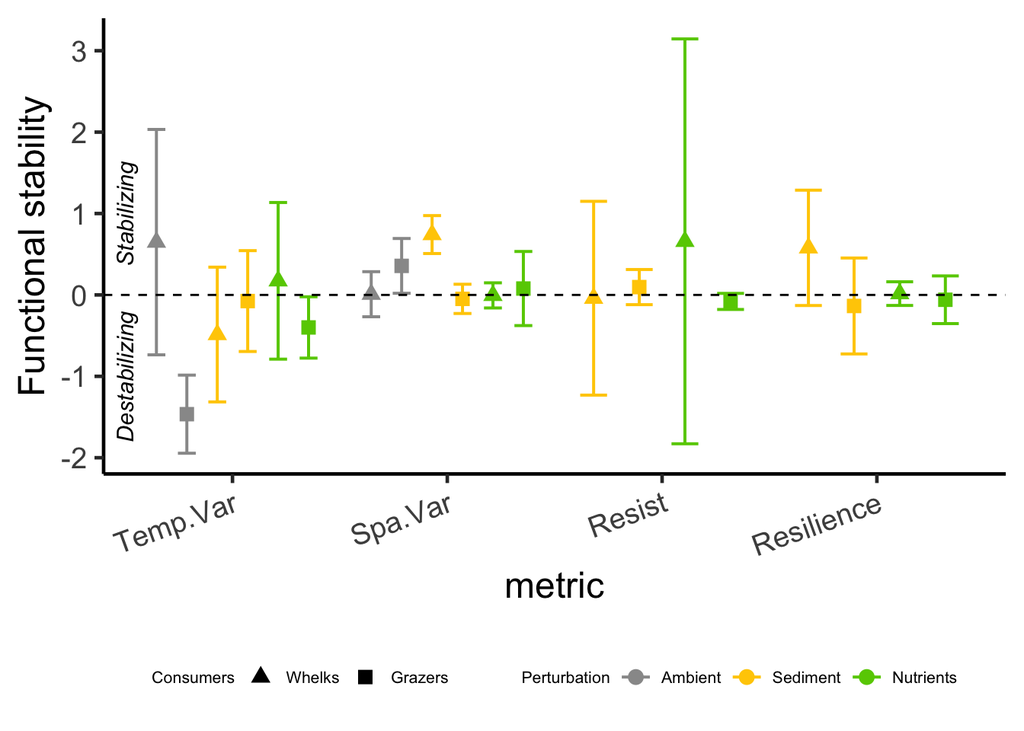

```r
contributions <- contributions %>%
  mutate(LRR_metric = ifelse(metric == "Resilience"|metric == "Resist"|metric == "Spa.Var", LRR_metric*-1, LRR_metric))

summary<-contributions %>%
  group_by(Treatment,metric)%>%
  summarise(mean=mean(LRR_metric),  sd = sd(LRR_metric), n = n())%>%
  mutate(se = sd/sqrt(n),lower.ci = mean - qt(1 - (0.05 / 2), n - 1) * se, upper.ci = mean + qt(1 - (0.05 / 2), n - 1) * se)%>%
  separate(Treatment, c("Diversity", "Nutrients","Sediment"))%>%
  unite(Disturbance,c("Nutrients","Sediment"),sep="_")%>%
  filter(Disturbance !='N1_S1')%>%
  mutate(metric = factor(metric,levels = c( "Temp.Var", "Spa.Var", "Resist", "Resilience")))%>%
  mutate(Diversity = factor(Diversity,levels = c("B", "A")))%>%
  mutate(Diversity = plyr::mapvalues(Diversity, from = c("B","A"), to = c("Whelks","Grazers")))%>%
  mutate(Disturbance = plyr::mapvalues(Disturbance, from = c("N0_S0","N0_S1","N1_S0"), to = c("Ambient", "Sediment","Nutrients")))%>%
 mutate(Disturbance = factor(Disturbance,levels = c("Ambient", "Sediment","Nutrients")))

sum_Func<-ggplot(summary, aes(x=metric, y=mean, Diversity)) +
  geom_errorbar(aes(colour = Disturbance, shape = Diversity, ymin=lower.ci, ymax=upper.ci),      position=position_dodge(0.85), width = 0.5, size = 0.7) +
  geom_point(aes(colour = Disturbance, shape = Diversity),position=position_dodge(0.85), size = 3)+
  ylab("Functional stability") +
  geom_hline(yintercept = 0, linetype="dashed") +
  theme_classic(base_size = 18)+
  theme(axis.text.x=element_text(angle=20,hjust=1),legend.position = "bottom", legend.title=element_text(size=8),legend.text = element_text(size=8)) +
  annotate("text", x = 0.5, y = -1, label="Destabilizing", color = "black",size = 4, angle=90,fontface = "italic")+
  annotate("text", x = 0.5, y = 1, label="Stabilizing", color = "black",size = 4, angle=90,fontface = "italic")+
  scale_colour_manual(values=c("#999999", "#FFCC00","#66CC00"), name="Perturbation") +
  scale_shape_manual(values=c(17,15), name="Consumers")

sum_Func
```

Want to run t-tests for each combination of metric x treatment two-tailed tests to see if greater OR less than zero.

t-tests rely on the same confidence intervals that we have plotted so, grazer (i.e Diversity treat A) contributions to temp var (no stressor and nutrients) are less than zero. Grazer contribution to spa var (no stressor) and predator contribution to spa var (sediment) are greater than zero.  
but with multiple comparisons p values are adjusted and some no longer significant.

```r
test_func<-contributions %>%
  filter(Treatment != "A_N1_S1" & Treatment != "B_N1_S1")%>%
  group_by(metric, Treatment, Diversity) %>%
  summarise(pval = t.test(x = LRR_metric, mu = 0)$p.value,  # default is two.sided
            tval = t.test(x = LRR_metric, mu = 0)$statistic,
            norm = shapiro.test(x = LRR_metric)$p.value)

test_func %>%
  group_by(metric) %>%
  mutate(pval.adj = p.adjust (pval, method='holm'))
```

```
## # A tibble: 20 × 7
## # Groups:   metric [4]
##    metric     Treatment Diversity     pval    tval     norm pval.adj
##    <chr>      <chr>     <chr>        <dbl>   <dbl>    <dbl>    <dbl>
##  1 Resilience A_N0_S1   A         0.557    -0.639  0.00356   1
##  2 Resilience A_N1_S0   A         0.604    -0.563  0.168     1
##  3 Resilience B_N0_S1   B         0.0860    2.27   0.309     0.344
##  4 Resilience B_N1_S0   B         0.774     0.307  0.710     1
##  5 Resist     A_N0_S1   A         0.283     1.24   0.0890    0.849
##  6 Resist     A_N1_S0   A         0.0887   -2.24   0.870     0.355
##  7 Resist     B_N0_S1   B         0.929    -0.0944 0.00100   1
##  8 Resist     B_N1_S0   B         0.503     0.735  0.000290  1
##  9 Spa.Var    A_N0_S0   A         0.0409    2.60   0.460     0.205
## 10 Spa.Var    A_N0_S1   A         0.534    -0.659  0.597     1
## 11 Spa.Var    A_N1_S0   A         0.687     0.422  0.917     1
## 12 Spa.Var    B_N0_S0   B         0.941     0.0767 0.929     1
## 13 Spa.Var    B_N0_S1   B         0.000236  7.79   0.168     0.00142
## 14 Spa.Var    B_N1_S0   B         0.930    -0.0911 0.684     1
## 15 Temp.Var   A_N0_S0   A         0.00106  -8.48   0.583     0.00637
## 16 Temp.Var   A_N0_S1   A         0.752    -0.338  0.0148    1
## 17 Temp.Var   A_N1_S0   A         0.0422   -2.94   0.182     0.211
## 18 Temp.Var   B_N0_S0   B         0.263     1.30   0.357     0.790
## 19 Temp.Var   B_N0_S1   B         0.178    -1.63   0.145     0.712
## 20 Temp.Var   B_N1_S0   B         0.643     0.500  0.147     1
```

```r
test_func %>%
  group_by(metric, Diversity) %>%
  mutate(pval.adj = p.adjust (pval, method='BH'))  # reduce comparisons from 6/4 to 3/2 ie each stressor treat within diversity
```

```
## # A tibble: 20 × 7
## # Groups:   metric, Diversity [8]
##    metric     Treatment Diversity     pval    tval     norm pval.adj
##    <chr>      <chr>     <chr>        <dbl>   <dbl>    <dbl>    <dbl>
##  1 Resilience A_N0_S1   A         0.557    -0.639  0.00356  0.604
##  2 Resilience A_N1_S0   A         0.604    -0.563  0.168    0.604
##  3 Resilience B_N0_S1   B         0.0860    2.27   0.309    0.172
##  4 Resilience B_N1_S0   B         0.774     0.307  0.710    0.774
##  5 Resist     A_N0_S1   A         0.283     1.24   0.0890   0.283
##  6 Resist     A_N1_S0   A         0.0887   -2.24   0.870    0.177
##  7 Resist     B_N0_S1   B         0.929    -0.0944 0.00100  0.929
##  8 Resist     B_N1_S0   B         0.503     0.735  0.000290 0.929
##  9 Spa.Var    A_N0_S0   A         0.0409    2.60   0.460    0.123
## 10 Spa.Var    A_N0_S1   A         0.534    -0.659  0.597    0.687
## 11 Spa.Var    A_N1_S0   A         0.687     0.422  0.917    0.687
## 12 Spa.Var    B_N0_S0   B         0.941     0.0767 0.929    0.941
## 13 Spa.Var    B_N0_S1   B         0.000236  7.79   0.168    0.000709
## 14 Spa.Var    B_N1_S0   B         0.930    -0.0911 0.684    0.941
## 15 Temp.Var   A_N0_S0   A         0.00106  -8.48   0.583    0.00318
## 16 Temp.Var   A_N0_S1   A         0.752    -0.338  0.0148   0.752
## 17 Temp.Var   A_N1_S0   A         0.0422   -2.94   0.182    0.0633
## 18 Temp.Var   B_N0_S0   B         0.263     1.30   0.357    0.395
## 19 Temp.Var   B_N0_S1   B         0.178    -1.63   0.145    0.395
## 20 Temp.Var   B_N1_S0   B         0.643     0.500  0.147    0.643
```

```r
comparisons_func<-test_func %>%
  group_by(metric) %>%
  mutate(pval.adj = p.adjust (pval, method='BH'))%>%
  group_by(metric, Diversity) %>%
  mutate(pval.adj_A = p.adjust (pval, method='BH'))%>%
  separate(Treatment, c("Diversity", "Nutrients", "Sediment"), sep='_', remove = FALSE) %>%
  unite(Stressor, c("Nutrients", "Sediment"), sep = "_", remove = FALSE)%>%
  group_by(metric, Stressor) %>%
  mutate(pval.adj_B = p.adjust (pval, method='BH')) %>%
  arrange(desc(metric), Nutrients, Sediment, desc(Diversity)) %>%
  mutate(Diversity = plyr::mapvalues(Diversity, from = c("A","B"), to = c("Grazers","Whelks")))
comparisons_func$response <- "Functional"


test_func <- test_func %>%
  group_by(metric) %>%
  mutate(pval.adj = p.adjust (pval, method='BH'))

contributions %>%
  filter(metric == "Resilience", Treatment== "A_N0_S1")%>%
  summarise(pval = t.test(x = LRR_metric, mu = 0)$p.value,
            tval = t.test(x = LRR_metric, mu = 0)$statistic,
            conf = t.test(x = LRR_metric, mu = 0)$conf.int)
```

```
## # A tibble: 2 × 4
## # Groups:   metric [1]
##   metric      pval   tval   conf
##   <chr>      <dbl>  <dbl>  <dbl>
## 1 Resilience 0.557 -0.639 -0.725
## 2 Resilience 0.557 -0.639  0.454
```

```r
test_func <- test_func %>%
  separate(Treatment, c("Diversity", "Nutrients", "Sediment"), sep='_') %>%
  arrange(desc(metric), Nutrients, Sediment, desc(Diversity))

print.data.frame(test_func)
```

```
##        metric Diversity Nutrients Sediment         pval        tval
## 1    Temp.Var         B        N0       S0 0.2632710781  1.30058108
## 2    Temp.Var         A        N0       S0 0.0010611723 -8.47772810
## 3    Temp.Var         B        N0       S1 0.1780461022 -1.63185456
## 4    Temp.Var         A        N0       S1 0.7524659041 -0.33784556
## 5    Temp.Var         B        N1       S0 0.6434293497  0.49984581
## 6    Temp.Var         A        N1       S0 0.0422062448 -2.94434256
## 7     Spa.Var         B        N0       S0 0.9413361644  0.07672582
## 8     Spa.Var         A        N0       S0 0.0409024469  2.59561284
## 9     Spa.Var         B        N0       S1 0.0002362613  7.78698795
## 10    Spa.Var         A        N0       S1 0.5344748681 -0.65879861
## 11    Spa.Var         B        N1       S0 0.9303527349 -0.09113371
## 12    Spa.Var         A        N1       S0 0.6874857137  0.42235026
## 13     Resist         B        N0       S1 0.9293084048 -0.09443048
## 14     Resist         A        N0       S1 0.2831428940  1.23881032
```

[output cut: 27 more lines]

```r
test_func$tval
```

```
##           t           t           t           t           t           t
##  1.30058108 -8.47772810 -1.63185456 -0.33784556  0.49984581 -2.94434256
##           t           t           t           t           t           t
##  0.07672582  2.59561284  7.78698795 -0.65879861 -0.09113371  0.42235026
##           t           t           t           t           t           t
## -0.09443048  1.23881032  0.73480838 -2.23960165  2.26660563 -0.63914126
##           t           t
##  0.30660477 -0.56277879
```

```r
test_func$response <- "Functional"


#write.csv(test, file = "ttest_data_function.csv")

test_func_edit<-contributions %>%
  filter(Treatment != "A_N1_S1" & Treatment != "B_N1_S1")%>%
  separate(Treatment, c("Diversity", "Nutrients", "Sediment"), sep='_', remove = FALSE) %>%
  unite(Stressor, c("Nutrients", "Sediment"), sep = "_")%>%
  group_by(metric, Diversity, Stressor, Treatment) %>%
  summarise(pval = t.test(x = LRR_metric, mu = 0)$p.value,  # default is two.sided
            tval = t.test(x = LRR_metric, mu = 0)$statistic,
            norm = shapiro.test(x = LRR_metric)$p.value)


test_func_edit %>%
  group_by(metric, Stressor) %>%
  mutate(pval.adj = p.adjust (pval, method='BH'))
```

```
## # A tibble: 20 × 8
## # Groups:   metric, Stressor [10]
##    metric     Diversity Stressor Treatment     pval    tval     norm pval.adj
##    <chr>      <chr>     <chr>    <chr>        <dbl>   <dbl>    <dbl>    <dbl>
##  1 Resilience A         N0_S1    A_N0_S1   0.557    -0.639  0.00356  0.557
##  2 Resilience A         N1_S0    A_N1_S0   0.604    -0.563  0.168    0.774
##  3 Resilience B         N0_S1    B_N0_S1   0.0860    2.27   0.309    0.172
##  4 Resilience B         N1_S0    B_N1_S0   0.774     0.307  0.710    0.774
##  5 Resist     A         N0_S1    A_N0_S1   0.283     1.24   0.0890   0.566
##  6 Resist     A         N1_S0    A_N1_S0   0.0887   -2.24   0.870    0.177
##  7 Resist     B         N0_S1    B_N0_S1   0.929    -0.0944 0.00100  0.929
##  8 Resist     B         N1_S0    B_N1_S0   0.503     0.735  0.000290 0.503
##  9 Spa.Var    A         N0_S0    A_N0_S0   0.0409    2.60   0.460    0.0818
## 10 Spa.Var    A         N0_S1    A_N0_S1   0.534    -0.659  0.597    0.534
## 11 Spa.Var    A         N1_S0    A_N1_S0   0.687     0.422  0.917    0.930
## 12 Spa.Var    B         N0_S0    B_N0_S0   0.941     0.0767 0.929    0.941
## 13 Spa.Var    B         N0_S1    B_N0_S1   0.000236  7.79   0.168    0.000473
## 14 Spa.Var    B         N1_S0    B_N1_S0   0.930    -0.0911 0.684    0.930
## 15 Temp.Var   A         N0_S0    A_N0_S0   0.00106  -8.48   0.583    0.00212
## 16 Temp.Var   A         N0_S1    A_N0_S1   0.752    -0.338  0.0148   0.752
## 17 Temp.Var   A         N1_S0    A_N1_S0   0.0422   -2.94   0.182    0.0844
## 18 Temp.Var   B         N0_S0    B_N0_S0   0.263     1.30   0.357    0.263
## 19 Temp.Var   B         N0_S1    B_N0_S1   0.178    -1.63   0.145    0.356
## 20 Temp.Var   B         N1_S0    B_N1_S0   0.643     0.500  0.147    0.643
```

## Predicting multiple stressor effects

We predicted the combined contribution of consumers to the various dimensions of stability in response to multiple stressors based upon the sum of their contributions to individual stressors, effectively testing for interactive effects of stressors as departure from the additive model.

We randomly selected combinations of contributions of consumers to algal stability in response to elevated sediments and nutrient enrichment (that is, one contribution measurement selected randomly from one of the plots belonging to each single stressor treatment) by bootstrapping (1,000 times) and then summing the two values together. These bootstrapped predicted values were compared with observed multi-stressor contributions, after correcting for original sample size (n = 5, or n = 7 for spatial variability).

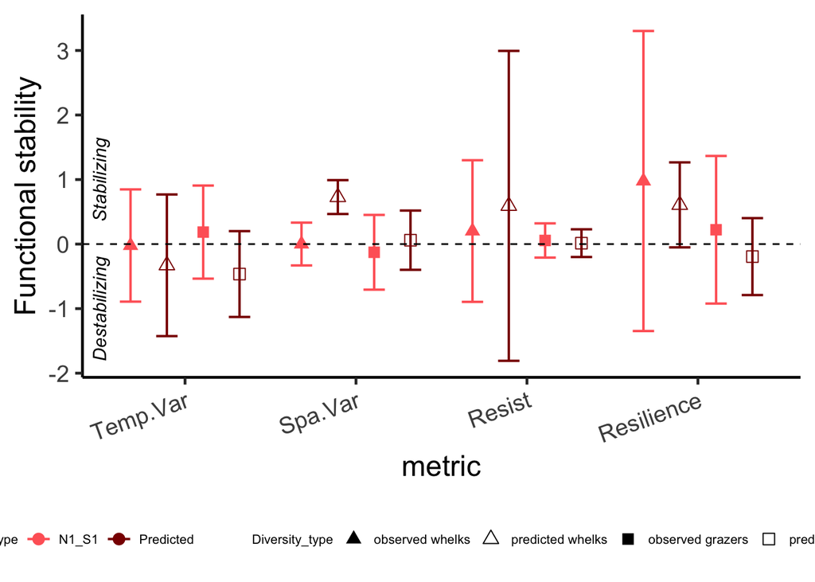

```r
contributions <- contributions%>%
  separate(Treatment, c("Diversity", "Nutrients","Sediment"))%>%
  unite(Disturbance,c("Nutrients","Sediment"),sep="_")%>%
  filter(Disturbance != 'N0_S0')

predict<-lapply(contributions$metric %>% unique,function(i){
  y = contributions %>%
     filter(metric == i & Disturbance == "N0_S1" & Diversity == "A") %>% nrow
  lapply(c("A","B"), function(k){
    lapply(c("N0_S1","N1_S0"),function(j){
      x = contributions %>%
       filter(metric == i & Disturbance == j & Diversity == k)
      x$LRR_metric[sample(1:nrow(x),1000,replace = T)]
    }) %>%
      Reduce("+",.) %>%
      data_frame(type = "Predicted", Diversity = k, metric = i, LRR_metric = . ,n=y)
  })  %>% Reduce("rbind",.)
}) %>% Reduce("rbind",.)

contributions<-contributions%>%
  group_by(metric, Diversity, Disturbance)%>%
  summarise(n = n())%>%
  left_join(contributions,.)%>%
  rename(type = Disturbance)

predict<-rbind(as_data_frame(contributions %>%
  filter(type == "N1_S1")%>%
 select (type, Diversity, metric, LRR_metric, n)), predict)

predict_summary<-predict %>%
  group_by(type, Diversity, metric)%>%
  summarise(mean=mean(LRR_metric),  sd = sd(LRR_metric), n = unique(n))%>%
  mutate(se = sd/sqrt(n),lower.ci = mean - qt(1 - (0.05 / 2), n - 1) * se, upper.ci = mean + qt(1 - (0.05 / 2), n - 1) * se)%>%
  ungroup(type, Diversity,metric) %>%
  unite("Diversity_type", Diversity, type, remove = FALSE)%>%
  mutate(metric = factor(metric,levels = c( "Temp.Var", "Spa.Var", "Resist", "Resilience")))%>%
  mutate(Diversity_type = factor(Diversity_type,levels = c( "B_N1_S1", "B_Predicted", "A_N1_S1", "A_Predicted")))%>%
  mutate(Diversity_type = plyr::mapvalues(Diversity_type, from = c("B_N1_S1", "B_Predicted", "A_N1_S1", "A_Predicted"), to = c("observed whelks","predicted whelks","observed grazers","predicted grazers")))

pred_Func<-ggplot(predict_summary, aes(x=metric, y=mean, Diversity_type)) +
  geom_errorbar(aes(shape = Diversity_type, colour = type, ymin=lower.ci, ymax=upper.ci),      position=position_dodge(0.85), width = 0.5, size = 0.7) +
  geom_point(aes(shape = Diversity_type,colour = type),position=position_dodge(0.85), size = 3)+
  ylab("Functional stability") +
  geom_hline(yintercept = 0, linetype="dashed") +
  theme_classic(base_size = 18)+
  theme(axis.text.x=element_text(angle=20,hjust=1),legend.position = "bottom", legend.title=element_text(size=8),legend.text = element_text(size=8)) +
  annotate("text", x = 0.5, y = -1, label="Destabilizing", color = "black",size = 4, angle=90,fontface = "italic")+
  annotate("text", x = 0.5, y = 1, label="Stabilizing", color = "black",size = 4, angle=90,fontface = "italic")+  scale_shape_manual(values=c( 17,2,15,0))+ scale_colour_manual(values = c("#FF6666", "dark red"))

pred_Func
```

Can do t-test for predicted and observed, again to see what is diff from zero. But doesn’t work cos of samples sizes for bootstrapped data.

Then for predator contribution to spa var. will check for equal variance first (is equal) so continue with standard 2 sample t test. After accounting for 2 comparisons with BH. For all other metrics predict vs observed are not sig different.

t_test is just a pipeable wrapper for t.test (package = rstatix) but cannot manually dictate how many comparisons to adjust p vals for.

```r
test<-predict %>%
  group_by(metric, Diversity, type) %>%
  summarise(pval = t.test(x = LRR_metric, mu = 0)$p.value,  # default is two.sided
            tval = t.test(x = LRR_metric, mu = 0)$statistic)

var.test(filter(predict, metric == "Spa.Var" & Diversity == "B", type == "N1_S1")$LRR_metric, filter(predict, metric == "Spa.Var" & Diversity == "B", type == "Predicted")$LRR_metric)
```

```
##
##  F test to compare two variances
##
## data:  filter(predict, metric == "Spa.Var" & Diversity == "B", type == "N1_S1")$LRR_metric and filter(predict, metric == "Spa.Var" & Diversity == "B", type == "Predicted")$LRR_metric
## F = 1.5967, num df = 6, denom df = 999, p-value = 0.2895
## alternative hypothesis: true ratio of variances is not equal to 1
## 95 percent confidence interval:
##  0.659576 7.753435
## sample estimates:
## ratio of variances
##           1.596739
```

```r
fd<-predict %>%
  filter(metric == "Spa.Var" & Diversity == "B")%>%
  t_test(LRR_metric ~ type)

fd$p
```

```
## [1] 0.00169
```

```r
p.adjust(fd$p, 'BH', n = 2)
```

```
## [1] 0.00338
```

```r
predict %>%
  filter(metric == "Spa.Var" & Diversity == "B", type == "Predicted")%>%
  t_test(LRR_metric ~ 1, mu = 0)
```

```
## # A tibble: 1 × 7
##   .y.        group1 group2         n statistic    df     p
## * <chr>      <chr>  <chr>      <int>     <dbl> <dbl> <dbl>
## 1 LRR_metric 1      null model  1000      81.2   999     0
```

```r
# predict %>%
#  filter(metric == "Resilience" & Diversity == "A") %>%
#  t_test(LRR_metric ~ type )
```

# Compositional Stability

## Stability metrics

For compositional stability, we originally calculated bray-curtis distance matrices from the log10 x +1 transformed species abundance data in PRIMER V6. But have redone all the analysis in R, all metrics were calculated with the aim of being analogous to functional measures, where possible. As for funtional stability, we calculate 4 different metrics using algal cover data from the time period following the perturbations (months 6 to 15).

### Temporal variability

Mean Euclidean distance from each experimental plot, on every census (months 6 to 12), to the plot centroid, based on Bray–Curtis dissimilarity matrices calculated from algal cover data.

```r
dat<- data%>%
   filter(Time > 5 & Time < 13)%>%
   unite("Treatment_Time",Treatment, Time, remove = FALSE)

dist_bc <- vegdist(log10(1+dat[9:43]), method = 'bray')
mod <- betadisper(dist_bc, dat$Plot)
dat$dist <- mod$distances

Temp_Var_Comp<- dat  %>%
  group_by(Plot)%>%
  summarise(Temp.Var = mean(dist), Diversity = unique(Diversity), Treatment = unique(Treatment) )
```

### Spatial variability

Mean Euclidean distance from each experimental plot to their grazer treatment centroid, calculated separately for each census (months 6 to 12), based on Bray–Curtis dissimilarity matrices calculated from algal cover data.

```r
dat<- data%>%
   filter(Time > 5 & Time < 13)%>%
   unite("Treatment_Time",Treatment, Time, remove = FALSE)

dist_bc <- vegdist(log10(1+dat[9:43]), method = 'bray')
mod <- betadisper(dist_bc, dat$Treatment_Time)  ####### gives mean distance between plots and their centroid

Spatial_Var_Comp<-aggregate(mod$distances,list(dat$Treatment_Time),mean)%>%
 rename(Spa.Var = x, centroid = Group.1)
```

### Resistance, Resilience

For Resistance & Resilience, we used pairwise distances in the same way as LRR values for functional stability, calculating metrics from the temporal trajectory of these LRR values. As for functional stability, these metrics are all associated with a perturbation and can only be calculated by comparing algal assemblage in perturbed treatments to assemblages in unperturbed treatments.

Because of heterogeneous dispersions between consumer loss treatments (ANOVA results below), we calculated the log response ratio of the mean Euclidian distance between all plots in a given perturbed treatment and their own centroid and that from a perturbed plot to the centroid of the unperturbed plots in the corresponding consumer loss treatment. i.e. ln(mean Euclidian distance between all plots in a given perturbed treatment and their own centroid/Euclidian distance from a perturbed plot to the centroid of the unperturbed plots in the corresponding consumer loss treatment)

This effectively takes into account the variabilty amongst plots for a given consumer loss group.

We calculated this LRR for every perturbed plot at the time point at the end of the pertubation phase and during the three month recovery phase after the perturbations (month 12 - 15). And then calculated the remaining stability metrics in exactly the same way as for functional stability.

```r
dat<- data%>%
   filter(Time > 11) %>%
   unite("Treatment_Time", Treatment, Time, remove = FALSE)%>%
   unite("Treatment_Time_Plot",Treatment, Time, Plot, remove = FALSE)

dat<-dat[order(dat$Treatment_Time_Plot),]
dis <- vegdist(log10(1+dat[10:44 ]), method = 'bray')

mod <- betadisper(dis, dat$Treatment)
anova(mod) ### check for dispersion between treatments
```

```
## Analysis of Variance Table
##
## Response: Distances
##            Df Sum Sq  Mean Sq F value    Pr(>F)
## Groups     15 1.1806 0.078708  3.4175 2.219e-05 ***
## Residuals 304 7.0014 0.023031
## ---
## Signif. codes:  0 '***' 0.001 '**' 0.01 '*' 0.05 '.' 0.1 ' ' 1
```

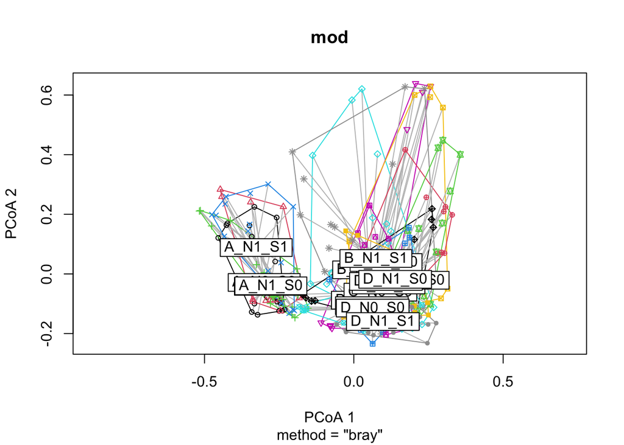

```r
plot(mod)
```

```r
fullmod <- betadisper(dis, dat$Treatment_Time)

fancier_function <- function(X,Y,Z){
  tmp <- Z$vectors[X,] ### the positions of each plot in all pCoA axis (n of plots -1)
  tmp.pos <- tmp[Z$eig>=0]   ### the real part
  tmp.neg <- tmp[Z$eig<0]   ### the imaginary part

  tmp.cent <- Z$centroids[Y,] ### the positions of each centroid
  tmp.cent.pos <- tmp.cent[Z$eig>=0]
  tmp.cent.neg <- tmp.cent[Z$eig<0]

  real.euc <- dist(t(data.frame(tmp.pos,tmp.cent.pos))) ### real distances
  imag.euc<- dist(t(data.frame(tmp.neg,tmp.cent.neg))) ### imaginary distances
  as.vector(sqrt(abs(real.euc^2 - imag.euc^2))) # need the sqrt of the difference between real and imaginary parts following Anderson 2006
}

Test<-sapply(1:5, function(X) fancier_function(X,"A_N0_S0_12", fullmod)) # can compare Test vs head(fullmod$distances) to check its working properly

names<-dat$Treatment_Time_Plot %>% as.character()

## converts Treatment_Time_Plot to Treatment_Time using "regular expressions"
tmp2 <- data.frame(Treatment_Time_Plot=names,centroid=gsub("_[^_]+$", "", names),stringsAsFactors = F) # gsub looks for something that starts with an underscore followed by a single or multiple letter or number at the end of the name and replaces it with "nothing" thus removing the last portion of the sampe name

tmp2$centroid<-sub("_N[0-1]_S[0-1]_","_N0_S0_",tmp2$centroid) ### converts to unperturbed centroid code
Test2<-sapply(1:320, function(X) fancier_function(X,tmp2$centroid[X], fullmod)) # now apply the funciton to every row in our mod 2 table for every centroid in our centroid table)

Distances<-cbind(Test2,tmp2)%>%
 rename(ED = Test2)%>%
   separate(Treatment_Time_Plot, c("Diversity", "Nutrients","Sediment", "Time","Plot"))%>%
  unite("Treatment_Time", Diversity, Nutrients, Sediment, Time, remove = FALSE)

dat<- data%>%
   filter(Time > 11)%>%
   unite("Treatment_Time",Treatment, Time, remove = FALSE)

dist_bc <- vegdist(log10(1+dat[9:43]), method = 'bray')
mod <- betadisper(dist_bc, dat$Treatment_Time)

Spatial_Var_Comp_recovery<-aggregate(mod$distances,list(dat$Treatment_Time),mean)%>%
 rename(Spa.Var = x, Treatment_Time = Group.1)

LRR_Comp<-left_join(Distances, Spatial_Var_Comp_recovery)%>%
  mutate(LRR_COMP = log(Spa.Var/ED))%>%
  mutate(Time = as.numeric(Time))%>%
  unite(Treatment,c("Diversity", "Nutrients","Sediment"),sep="_", remove = F)%>%
  select(Diversity, Treatment, Time, Plot, ED, Spa.Var, LRR_COMP)

LRR_Resist_Comp<-LRR_Comp%>%
  filter(Time == 12)%>%
  filter(Treatment != 'A_N0_S0' & Treatment != 'B_N0_S0' & Treatment != 'C_N0_S0' &   Treatment != 'D_N0_S0')%>%
  rename(Resist =  LRR_COMP)%>%
  select(Plot, Diversity, Treatment, Resist)

Resil_Comp<-lapply(1:nrow(LRR_Resist_Comp),function(i){
  X = LRR_Resist_Comp[i,]
  tmp =  filter(LRR_Comp,Plot == X$Plot)
  tmp<-lm(LRR_COMP~Time,data = tmp)
  coef2 = tmp$coefficients["Time"]
  data_frame(Plot=X$Plot,Resilience=coef2)
})%>% Reduce("rbind",.)
```

We can compile all the stabilty measures. For the few cases where perturbations increased similarity to control plots and, therefore, resulted in a positive resistance value, resilience was then multiplied by -1. We can plot the raw stabilty measures as boxplots.

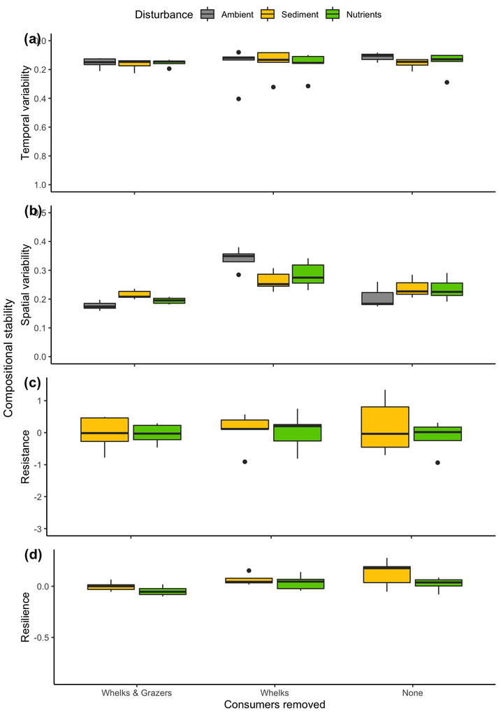

```r
Stability_metrics_Comp<-left_join(Resil_Comp,LRR_Resist_Comp)%>%
mutate(Resilience = ifelse(Resist >0, Resilience*-1, Resilience))%>%
  select(Plot,Diversity,Treatment,Resist,Resilience)%>%
  gather(key = metric, value = value, -Diversity, -Treatment, -Plot)%>%
  rename(rep = Plot)

Temp_Var_Comp<-Temp_Var_Comp %>%
  select(Plot,Diversity,Treatment,Temp.Var)%>%
  gather(key = metric, value = value, -Diversity, -Treatment, -Plot)%>%
  rename(rep = Plot)

Spatial_Var_Comp<-Spatial_Var_Comp%>%
  separate(centroid, c("Diversity", "Nutrients","Sediment", "Time"))%>%
  unite(Treatment,c("Diversity", "Nutrients","Sediment"),sep="_", remove = F)%>%
  select(-Nutrients, -Sediment)%>%
  gather(key = metric, value = value,  -Diversity, -Treatment, -Time)%>%
  rename(rep = Time )%>%
  mutate(rep = as.factor(rep))

x_Comp <-rbind(Stability_metrics_Comp, Temp_Var_Comp, Spatial_Var_Comp)%>%
  filter(Diversity != "D") %>%
  separate(Treatment, c("Diversity", "Nutrients","Sediment"), remove = F)%>%
  unite(Disturbance,c("Nutrients","Sediment"),sep="_")%>%
  filter(Disturbance != "N1_S1") %>%
  mutate(metric = factor(metric,levels = c( "Temp.Var", "Spa.Var", "Resist", "Resilience")))%>%
  mutate(Disturbance = plyr::mapvalues(Disturbance, from = c("N0_S0","N0_S1","N1_S0"), to = c("Ambient","Sediment","Nutrients")))%>%
  mutate(Disturbance = factor(Disturbance,levels = c("Ambient", "Sediment","Nutrients"))) %>%
 mutate(Diversity = plyr::mapvalues(Diversity, from = c("A","B","C"), to = c("Whelks & Grazers","Whelks","None")))%>%
  mutate(Diversity = factor(Diversity,levels = c("Whelks & Grazers","Whelks","None")))


B <-ggplot(data = subset(x_Comp,
              metric == "Temp.Var"), aes(x=Diversity, y=value)) +
  geom_boxplot(aes(fill = Disturbance)) +
  theme_classic()+
  ylab("Temporal variability") +
  scale_y_reverse(limits = c(1, 0), breaks = seq( 0,1, by = 0.2))+
  scale_fill_manual(values = c("#999999", "#FFCC00","#66CC00"))


D<-ggplot(data = subset(x_Comp,
              metric == "Spa.Var"), aes(x=Diversity, y=value)) +
  geom_boxplot(aes(fill = Disturbance)) +
  theme_classic()+
  ylab("Spatial variability") +
  ylim(0,0.5) +
  scale_fill_manual(values = c("#999999", "#FFCC00","#66CC00"))

FF<-ggplot(data = subset(x_Comp,
              metric == "Resist"), aes(x=Diversity, y=value)) +
  geom_boxplot(aes(fill = Disturbance)) +
  theme_classic()+
  ylab("Resistance") +
  ylim(-3,1.5) +
  scale_fill_manual(values = c("#FFCC00","#66CC00"))

H<-ggplot(data = subset(x_Comp,
              metric == "Resilience"), aes(x=Diversity, y=value)) +
  geom_boxplot(aes(fill = Disturbance)) +
  theme_classic()+
  ylab("Resilience") +
  xlab("Consumers removed") +
  ylim(-0.9,0.3) +
  scale_fill_manual(values = c("#FFCC00","#66CC00"))

P_Comp <- ggarrange(B + rremove("xlab") + rremove("x.text"), D + rremove("xlab") + rremove("x.text"),FF + rremove("xlab") + rremove("x.text"), H, heights = c(1, 1,1,1), ncol = 1, nrow = 4,common.legend = T, labels = c("(a)", "(b)", "(c)", "(d)"))

annotate_figure(P_Comp, left = text_grob("Compositional stability", rot = 90))
```

```r
P_full<- ggarrange(A + rremove("xlab") + rremove("x.text"), B + rremove("xylab") + rremove("x.text"), C + rremove("xlab") + rremove("x.text"), D + rremove("xylab") + rremove("x.text"), E + rremove("xlab") + rremove("x.text"), FF + rremove("xylab") + rremove("x.text"), G , H + rremove("ylab"), heights = c(1, 1,1,1), ncol = 2, nrow = 4,common.legend = T, labels = c("a", "b", "c", "d","e","f","g", "h"))
```

we also need subsets for main effects of consumer loss and disturbance on compositional resilience

## Consumer contributions

```r
H1<-ggplot(data = subset(x_Comp,
              metric == "Resilience"), aes(x=Diversity, y=value)) +
  geom_boxplot(aes()) +
  theme_classic()+
  ylab("Resilience") +
  xlab("Consumers removed") +
  ylim(-0.1,0.4) +
  scale_fill_manual(values = c("white")) +
  scale_x_discrete(labels=c("Whelks & Grazers" = "W & G", "Whelks" = "W",
                              "None" = "N"))

H2<-ggplot(data = subset(x_Comp,
              metric == "Resilience"), aes(x=Disturbance, y=value)) +
  geom_boxplot(aes(fill = Disturbance)) +
  theme_classic()+
  ylab("Resilience") +
  xlab("Consumers removed") +
  ylim(-0.1,0.4) +
  scale_fill_manual(values = c("#FFCC00","#66CC00")) +
  scale_x_discrete(labels=c("Sediment" = "S", "Nutrients" = "N"))

inset<- ggarrange(H1 + rremove("xylab") + rremove("y.text"), H2 + rremove("xylab") + rremove("y.text"), heights = c(1,1), ncol = 2, nrow = 1, legend = "none", labels = c("i", "ii"))
```

Calculated as for functional stability.

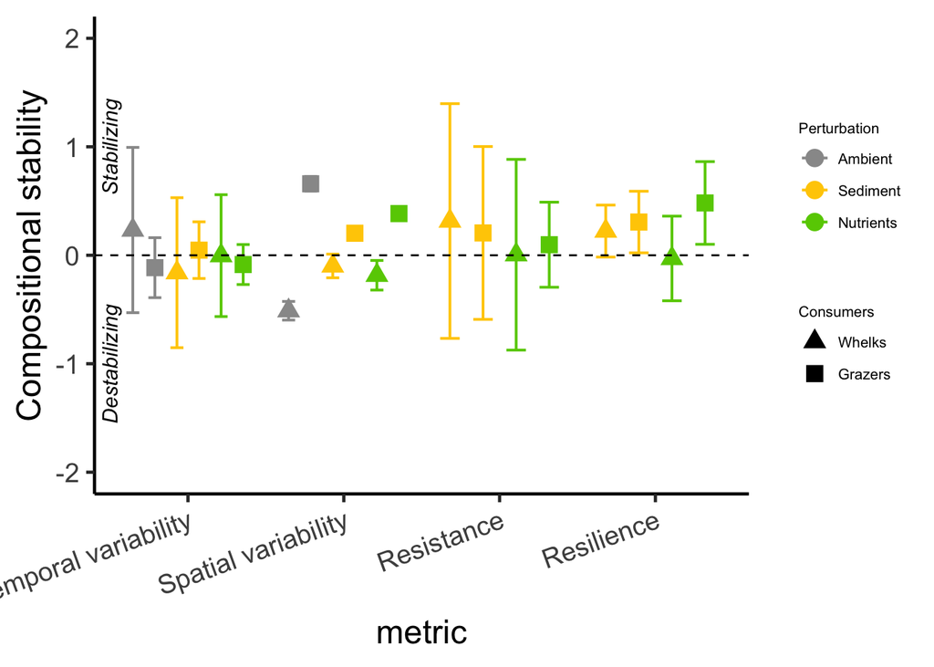

```r
contributions_Comp <-rbind(Stability_metrics_Comp, Temp_Var_Comp, Spatial_Var_Comp)%>%
  group_by(metric)%>%
  mutate(value = ifelse(metric == "Resist"|metric == "Resilience", rangestand(value)+0.01, value))

mean_metric_Comp<- contributions_Comp %>%
  filter(Diversity== "C"|Diversity== "B")%>%
  group_by(metric, Treatment)%>%
  summarise(mean =mean(value))

mean_metric_Comp$Treatment<- gsub("B", "A", mean_metric_Comp$Treatment)%>%
  gsub("C", "B", .)

contributions_Comp<-left_join(contributions_Comp,mean_metric_Comp)%>%
  filter(Diversity == 'A' | Diversity == 'B')%>%
  mutate(LRR_metric = log(value/mean))%>%
  mutate(LRR_metric = ifelse(metric == "Resilience"|metric == "Resist"|metric == "Spa.Var", LRR_metric*-1, LRR_metric))

summary_Comp<-contributions_Comp %>%
  group_by(Treatment,metric)%>%
  summarise(mean=mean(LRR_metric),  sd = sd(LRR_metric), n = n())%>%
  mutate(se = sd/sqrt(n),lower.ci = mean - qt(1 - (0.05 / 2), n - 1) * se, upper.ci = mean + qt(1 - (0.05 / 2), n - 1) * se)%>%
  separate(Treatment, c("Diversity", "Nutrients","Sediment"))%>%
  unite(Disturbance,c("Nutrients","Sediment"),sep="_")%>%
  filter(Disturbance !='N1_S1')%>%
  mutate(Diversity = factor(Diversity,levels = c("B", "A")))%>%
  mutate(Diversity = plyr::mapvalues(Diversity, from = c("B","A"), to = c("Whelks","Grazers")))%>%
  mutate(Disturbance = plyr::mapvalues(Disturbance, from = c("N0_S0","N0_S1","N1_S0"), to = c("Ambient", "Sediment","Nutrients")))%>%
 mutate(Disturbance = factor(Disturbance,levels = c("Ambient", "Sediment","Nutrients")))%>%
  mutate(metric = plyr::mapvalues(metric, from = c("Temp.Var", "Spa.Var", "Resist", "Resilience"), to = c("Temporal variability", "Spatial variability", "Resistance", "Resilience")))%>%
  mutate(metric = factor(metric,levels = c( "Temporal variability", "Spatial variability", "Resistance", "Resilience")))

sum_Comp<-ggplot(summary_Comp, aes(x=metric, y=mean, Diversity)) +
  geom_errorbar(aes(colour = Disturbance, shape = Diversity, ymin=lower.ci, ymax=upper.ci),      position=position_dodge(0.85), width = 0.5, size = 0.7) +
  geom_point(aes(colour = Disturbance, shape = Diversity),position=position_dodge(0.85), size = 4)+
  ylab("Compositional stability") +
  ylim(-2,2) +
  geom_hline(yintercept = 0, linetype="dashed") +
  theme_classic(base_size = 18)+
  theme(axis.text.x=element_text(angle=20,hjust=1), legend.title=element_text(size=8),legend.text = element_text(size=8)) +
  annotate("text", x = 0.5, y = -1, label="Destabilizing", color = "black",size = 4, angle=90,fontface = "italic")+
  annotate("text", x = 0.5, y = 1, label="Stabilizing", color = "black",size = 4, angle=90,fontface = "italic")+
  scale_colour_manual(values=c("#999999", "#FFCC00","#66CC00"), name="Perturbation")+
  scale_shape_manual(values=c(17,15), name="Consumers")

sum_Comp
```

```r
sum_Full<- ggarrange(sum_Func + rremove("xlab") + rremove("x.text"), sum_Comp+ rremove("xlab"), heights = c(1,1), ncol = 1, nrow = 2,common.legend = T, labels = c("(a)", "(b)"))
```

Want to run t-tests for each combination of metric x treatment

t-tests rely on exactly the same confidence intervals that we have plotted so, grazer (i.e Diversity treat A) contributions to resilience (both sediment and nutrients) are greater than zero, but predator contribution to resilience (sediment) is only marginal p = 0.06. All consumer contributions to spatial var are different from zero apart from predator/sediment (p = 0.069).

For spatial variability grazer vs predator contributions are different (for sediment) from one another despite predators not being different from zero.

```r
test_comp<-contributions_Comp %>%
  filter(Treatment != "A_N1_S1" & Treatment != "B_N1_S1") %>%
  group_by(metric, Treatment, Diversity) %>%
  summarise(pval = t.test(x = LRR_metric, mu = 0)$p.value,
            tval = t.test(x = LRR_metric, mu = 0)$statistic,
            norm = shapiro.test(x = LRR_metric)$p.value)

test_comp
```

```
## # A tibble: 20 × 6
## # Groups:   metric, Treatment [20]
##    metric     Treatment Diversity        pval     tval    norm
##    <chr>      <chr>     <chr>           <dbl>    <dbl>   <dbl>
##  1 Resilience A_N0_S1   A         0.0400        3.00   0.980
##  2 Resilience A_N1_S0   A         0.0246        3.51   0.946
##  3 Resilience B_N0_S1   B         0.0613        2.58   0.481
##  4 Resilience B_N1_S0   B         0.844        -0.210  0.757
##  5 Resist     A_N0_S1   A         0.513         0.717  0.233
##  6 Resist     A_N1_S0   A         0.529         0.688  0.591
##  7 Resist     B_N0_S1   B         0.464         0.810  0.00835
##  8 Resist     B_N1_S0   B         0.988         0.0154 0.262
##  9 Spa.Var    A_N0_S0   A         0.000000369  23.7    0.904
## 10 Spa.Var    A_N0_S1   A         0.000159      8.36   0.306
## 11 Spa.Var    A_N1_S0   A         0.00000151   18.7    0.464
## 12 Spa.Var    B_N0_S0   B         0.00000655  -14.6    0.440
## 13 Spa.Var    B_N0_S1   B         0.0688       -2.21   0.363
## 14 Spa.Var    B_N1_S0   B         0.0163       -3.31   0.682
## 15 Temp.Var   A_N0_S0   A         0.314        -1.15   0.627
## 16 Temp.Var   A_N0_S1   A         0.643         0.500  0.168
## 17 Temp.Var   A_N1_S0   A         0.268        -1.29   0.443
## 18 Temp.Var   B_N0_S0   B         0.445         0.847  0.130
## 19 Temp.Var   B_N0_S1   B         0.554        -0.645  0.306
## 20 Temp.Var   B_N1_S0   B         0.987        -0.0170 0.329
```

```r
comparisons_comp<-test_comp %>%
  group_by(metric) %>%
  mutate(pval.adj = p.adjust (pval, method='BH'))%>%
  group_by(metric, Diversity) %>%
  mutate(pval.adj_A = p.adjust (pval, method='BH'))%>%
  separate(Treatment, c("Diversity", "Nutrients", "Sediment"), sep='_', remove = FALSE) %>%
  unite(Stressor, c("Nutrients", "Sediment"), sep = "_", remove = FALSE)%>%
  group_by(metric, Stressor) %>%
  mutate(pval.adj_B = p.adjust (pval, method='BH')) %>%
  arrange(desc(metric), Nutrients, Sediment, desc(Diversity)) %>%
  mutate(Diversity = plyr::mapvalues(Diversity, from = c("A","B"), to = c("Grazers","Whelks")))
comparisons_comp$response <- "Compositional"

ttest_data_comparisons<-rbind(comparisons_func, comparisons_comp)
write.csv(ttest_data_comparisons, file = "ttest_data_comparisons.csv")

test_comp %>%
  group_by(metric, Diversity) %>%
  mutate(pval.adj = p.adjust (pval, method='BH'))
```

```
## # A tibble: 20 × 7
## # Groups:   metric, Diversity [8]
##    metric     Treatment Diversity        pval     tval    norm   pval.adj
##    <chr>      <chr>     <chr>           <dbl>    <dbl>   <dbl>      <dbl>
##  1 Resilience A_N0_S1   A         0.0400        3.00   0.980   0.0400
##  2 Resilience A_N1_S0   A         0.0246        3.51   0.946   0.0400
##  3 Resilience B_N0_S1   B         0.0613        2.58   0.481   0.123
##  4 Resilience B_N1_S0   B         0.844        -0.210  0.757   0.844
##  5 Resist     A_N0_S1   A         0.513         0.717  0.233   0.529
##  6 Resist     A_N1_S0   A         0.529         0.688  0.591   0.529
##  7 Resist     B_N0_S1   B         0.464         0.810  0.00835 0.927
##  8 Resist     B_N1_S0   B         0.988         0.0154 0.262   0.988
##  9 Spa.Var    A_N0_S0   A         0.000000369  23.7    0.904   0.00000111
## 10 Spa.Var    A_N0_S1   A         0.000159      8.36   0.306   0.000159
## 11 Spa.Var    A_N1_S0   A         0.00000151   18.7    0.464   0.00000226
## 12 Spa.Var    B_N0_S0   B         0.00000655  -14.6    0.440   0.0000197
## 13 Spa.Var    B_N0_S1   B         0.0688       -2.21   0.363   0.0688
## 14 Spa.Var    B_N1_S0   B         0.0163       -3.31   0.682   0.0245
## 15 Temp.Var   A_N0_S0   A         0.314        -1.15   0.627   0.471
## 16 Temp.Var   A_N0_S1   A         0.643         0.500  0.168   0.643
## 17 Temp.Var   A_N1_S0   A         0.268        -1.29   0.443   0.471
## 18 Temp.Var   B_N0_S0   B         0.445         0.847  0.130   0.831
## 19 Temp.Var   B_N0_S1   B         0.554        -0.645  0.306   0.831
## 20 Temp.Var   B_N1_S0   B         0.987        -0.0170 0.329   0.987
```

```r
test_comp %>%
  group_by(metric) %>%
  mutate(pval.adj = p.adjust (pval, method='BH'))
```

```
## # A tibble: 20 × 7
## # Groups:   metric [4]
##    metric     Treatment Diversity        pval     tval    norm   pval.adj
##    <chr>      <chr>     <chr>           <dbl>    <dbl>   <dbl>      <dbl>
##  1 Resilience A_N0_S1   A         0.0400        3.00   0.980   0.0801
##  2 Resilience A_N1_S0   A         0.0246        3.51   0.946   0.0801
##  3 Resilience B_N0_S1   B         0.0613        2.58   0.481   0.0817
##  4 Resilience B_N1_S0   B         0.844        -0.210  0.757   0.844
##  5 Resist     A_N0_S1   A         0.513         0.717  0.233   0.705
##  6 Resist     A_N1_S0   A         0.529         0.688  0.591   0.705
##  7 Resist     B_N0_S1   B         0.464         0.810  0.00835 0.705
##  8 Resist     B_N1_S0   B         0.988         0.0154 0.262   0.988
##  9 Spa.Var    A_N0_S0   A         0.000000369  23.7    0.904   0.00000221
## 10 Spa.Var    A_N0_S1   A         0.000159      8.36   0.306   0.000239
## 11 Spa.Var    A_N1_S0   A         0.00000151   18.7    0.464   0.00000452
## 12 Spa.Var    B_N0_S0   B         0.00000655  -14.6    0.440   0.0000131
## 13 Spa.Var    B_N0_S1   B         0.0688       -2.21   0.363   0.0688
## 14 Spa.Var    B_N1_S0   B         0.0163       -3.31   0.682   0.0196
## 15 Temp.Var   A_N0_S0   A         0.314        -1.15   0.627   0.772
## 16 Temp.Var   A_N0_S1   A         0.643         0.500  0.168   0.772
## 17 Temp.Var   A_N1_S0   A         0.268        -1.29   0.443   0.772
## 18 Temp.Var   B_N0_S0   B         0.445         0.847  0.130   0.772
## 19 Temp.Var   B_N0_S1   B         0.554        -0.645  0.306   0.772
## 20 Temp.Var   B_N1_S0   B         0.987        -0.0170 0.329   0.987
```

```r
test_comp %>%
  separate(Treatment, c("Diversity", "Nutrients", "Sediment"), sep='_') %>%
  arrange(desc(metric), Nutrients, Sediment, desc(Diversity))
```

```
## # A tibble: 20 × 7
## # Groups:   metric [4]
##    metric     Diversity Nutrients Sediment        pval     tval    norm
##    <chr>      <chr>     <chr>     <chr>          <dbl>    <dbl>   <dbl>
##  1 Temp.Var   B         N0        S0       0.445         0.847  0.130
##  2 Temp.Var   A         N0        S0       0.314        -1.15   0.627
##  3 Temp.Var   B         N0        S1       0.554        -0.645  0.306
##  4 Temp.Var   A         N0        S1       0.643         0.500  0.168
##  5 Temp.Var   B         N1        S0       0.987        -0.0170 0.329
##  6 Temp.Var   A         N1        S0       0.268        -1.29   0.443
##  7 Spa.Var    B         N0        S0       0.00000655  -14.6    0.440
##  8 Spa.Var    A         N0        S0       0.000000369  23.7    0.904
##  9 Spa.Var    B         N0        S1       0.0688       -2.21   0.363
## 10 Spa.Var    A         N0        S1       0.000159      8.36   0.306
## 11 Spa.Var    B         N1        S0       0.0163       -3.31   0.682
## 12 Spa.Var    A         N1        S0       0.00000151   18.7    0.464
## 13 Resist     B         N0        S1       0.464         0.810  0.00835
## 14 Resist     A         N0        S1       0.513         0.717  0.233
## 15 Resist     B         N1        S0       0.988         0.0154 0.262
## 16 Resist     A         N1        S0       0.529         0.688  0.591
## 17 Resilience B         N0        S1       0.0613        2.58   0.481
## 18 Resilience A         N0        S1       0.0400        3.00   0.980
## 19 Resilience B         N1        S0       0.844        -0.210  0.757
## 20 Resilience A         N1        S0       0.0246        3.51   0.946
```

```r
test_comp$response <- "Compositional"

print.data.frame(test_comp)
```

```
##        metric Treatment Diversity         pval         tval        norm
## 1  Resilience   A_N0_S1         A 4.004279e-02   2.99744390 0.979518622
## 2  Resilience   A_N1_S0         A 2.460141e-02   3.51316603 0.945848596
## 3  Resilience   B_N0_S1         B 6.131084e-02   2.58025635 0.481414833
## 4  Resilience   B_N1_S0         B 8.437460e-01  -0.21025278 0.757153835
## 5      Resist   A_N0_S1         A 5.131000e-01   0.71684252 0.232889447
## 6      Resist   A_N1_S0         A 5.289933e-01   0.68849421 0.591006036
## 7      Resist   B_N0_S1         B 4.635993e-01   0.80956175 0.008352417
## 8      Resist   B_N1_S0         B 9.884367e-01   0.01541844 0.261803908
## 9     Spa.Var   A_N0_S0         A 3.689100e-07  23.71633147 0.903634001
## 10    Spa.Var   A_N0_S1         A 1.592042e-04   8.36040923 0.306212204
## 11    Spa.Var   A_N1_S0         A 1.507616e-06  18.70411286 0.464144579
## 12    Spa.Var   B_N0_S0         B 6.554643e-06 -14.57121336 0.440470903
## 13    Spa.Var   B_N0_S1         B 6.884988e-02  -2.21308850 0.363188917
## 14    Spa.Var   B_N1_S0         B 1.630407e-02  -3.30509303 0.681923263
```

[output cut: 27 more lines]

```r
ttest_data<-rbind(test_func, test_comp)

write.csv(ttest_data, file = "ttest_data.csv")

test_comp_edit<-contributions_Comp %>%
  filter(Treatment != "A_N1_S1" & Treatment != "B_N1_S1")%>%
  separate(Treatment, c("Diversity", "Nutrients", "Sediment"), sep='_', remove = FALSE) %>%
  unite(Stressor, c("Nutrients", "Sediment"), sep = "_")%>%
  group_by(metric, Diversity, Stressor, Treatment) %>%
  summarise(pval = t.test(x = LRR_metric, mu = 0)$p.value,  # default is two.sided
            tval = t.test(x = LRR_metric, mu = 0)$statistic,
            norm = shapiro.test(x = LRR_metric)$p.value)


test_comp_edit %>%
  group_by(metric, Stressor) %>%
  mutate(pval.adj = p.adjust (pval, method='BH'))
```

```
## # A tibble: 20 × 8
## # Groups:   metric, Stressor [10]
##    metric     Diversity Stressor Treatment        pval     tval    norm pval.adj
##    <chr>      <chr>     <chr>    <chr>           <dbl>    <dbl>   <dbl>    <dbl>
##  1 Resilience A         N0_S1    A_N0_S1   0.0400        3.00   0.980    6.13e-2
##  2 Resilience A         N1_S0    A_N1_S0   0.0246        3.51   0.946    4.92e-2
##  3 Resilience B         N0_S1    B_N0_S1   0.0613        2.58   0.481    6.13e-2
##  4 Resilience B         N1_S0    B_N1_S0   0.844        -0.210  0.757    8.44e-1
##  5 Resist     A         N0_S1    A_N0_S1   0.513         0.717  0.233    5.13e-1
##  6 Resist     A         N1_S0    A_N1_S0   0.529         0.688  0.591    9.88e-1
##  7 Resist     B         N0_S1    B_N0_S1   0.464         0.810  0.00835  5.13e-1
##  8 Resist     B         N1_S0    B_N1_S0   0.988         0.0154 0.262    9.88e-1
##  9 Spa.Var    A         N0_S0    A_N0_S0   0.000000369  23.7    0.904    7.38e-7
## 10 Spa.Var    A         N0_S1    A_N0_S1   0.000159      8.36   0.306    3.18e-4
## 11 Spa.Var    A         N1_S0    A_N1_S0   0.00000151   18.7    0.464    3.02e-6
## 12 Spa.Var    B         N0_S0    B_N0_S0   0.00000655  -14.6    0.440    6.55e-6
## 13 Spa.Var    B         N0_S1    B_N0_S1   0.0688       -2.21   0.363    6.88e-2
## 14 Spa.Var    B         N1_S0    B_N1_S0   0.0163       -3.31   0.682    1.63e-2
## 15 Temp.Var   A         N0_S0    A_N0_S0   0.314        -1.15   0.627    4.45e-1
## 16 Temp.Var   A         N0_S1    A_N0_S1   0.643         0.500  0.168    6.43e-1
## 17 Temp.Var   A         N1_S0    A_N1_S0   0.268        -1.29   0.443    5.35e-1
## 18 Temp.Var   B         N0_S0    B_N0_S0   0.445         0.847  0.130    4.45e-1
## 19 Temp.Var   B         N0_S1    B_N0_S1   0.554        -0.645  0.306    6.43e-1
## 20 Temp.Var   B         N1_S0    B_N1_S0   0.987        -0.0170 0.329    9.87e-1
```

```r
var.test(filter(contributions_Comp, metric == "Spa.Var" & Treatment == "B_N0_S1")$LRR_metric,
         filter(contributions_Comp, metric == "Spa.Var" & Treatment == "A_N0_S1")$LRR_metric)
```

```
##
##  F test to compare two variances
##
## data:  filter(contributions_Comp, metric == "Spa.Var" & Treatment == "B_N0_S1")$LRR_metric and filter(contributions_Comp, metric == "Spa.Var" & Treatment == "A_N0_S1")$LRR_metric
## F = 3.364, num df = 6, denom df = 6, p-value = 0.1655
## alternative hypothesis: true ratio of variances is not equal to 1
## 95 percent confidence interval:
##   0.5780337 19.5777522
## sample estimates:
## ratio of variances
##           3.364016
```

```r
test1<-contributions_Comp %>%
  filter(metric == "Spa.Var" & Treatment == "B_N0_S1" |metric == "Spa.Var" & Treatment == "A_N0_S1" )%>%
  t_test(LRR_metric ~ Treatment)

p.adjust(test1$p, n = 3)  # 3 comparisons between grazers and predators, one for each stressor treatment.
```

```
## [1] 0.000576
```

```r
var.test(filter(contributions_Comp, metric == "Spa.Var" & Treatment == "A_N0_S1")$LRR_metric,
         filter(contributions_Comp, metric == "Spa.Var" & Treatment == "A_N1_S0")$LRR_metric)
```

```
##
##  F test to compare two variances
##
## data:  filter(contributions_Comp, metric == "Spa.Var" & Treatment == "A_N0_S1")$LRR_metric and filter(contributions_Comp, metric == "Spa.Var" & Treatment == "A_N1_S0")$LRR_metric
## F = 1.3998, num df = 6, denom df = 6, p-value = 0.6934
## alternative hypothesis: true ratio of variances is not equal to 1
## 95 percent confidence interval:
##  0.2405225 8.1463938
## sample estimates:
## ratio of variances
##           1.399783
```

```r
test2<-contributions_Comp %>%
  filter(metric == "Spa.Var" & Treatment == "A_N0_S1" |metric == "Spa.Var" & Treatment == "A_N1_S0" )%>%
  t_test(LRR_metric ~ Treatment)

p.adjust(test2$p, n = 3)  # 3 comparisons between grazers stressor treatments.
```

```
## [1] 0.000336
```

```r
var.test(filter(contributions_Comp, metric == "Spa.Var" & Treatment == "A_N1_S0")$LRR_metric,
         filter(contributions_Comp, metric == "Spa.Var" & Treatment == "A_N0_S0")$LRR_metric)
```

```
##
##  F test to compare two variances
##
## data:  filter(contributions_Comp, metric == "Spa.Var" & Treatment == "A_N1_S0")$LRR_metric and filter(contributions_Comp, metric == "Spa.Var" & Treatment == "A_N0_S0")$LRR_metric
## F = 0.54684, num df = 6, denom df = 6, p-value = 0.4813
## alternative hypothesis: true ratio of variances is not equal to 1
## 95 percent confidence interval:
##  0.09396222 3.18245970
## sample estimates:
## ratio of variances
##          0.5468373
```

```r
test3<-contributions_Comp %>%
  filter(metric == "Spa.Var" & Treatment == "A_N1_S0" |metric == "Spa.Var" & Treatment == "A_N0_S0" )%>%
  t_test(LRR_metric ~ Treatment)

p.adjust(test3$p, n = 3)
```

```
## [1] 2.025e-05
```

```r
var.test(filter(contributions_Comp, metric == "Spa.Var" & Treatment == "A_N0_S1")$LRR_metric,
         filter(contributions_Comp, metric == "Spa.Var" & Treatment == "A_N0_S0")$LRR_metric)
```

```
##
##  F test to compare two variances
##
## data:  filter(contributions_Comp, metric == "Spa.Var" & Treatment == "A_N0_S1")$LRR_metric and filter(contributions_Comp, metric == "Spa.Var" & Treatment == "A_N0_S0")$LRR_metric
## F = 0.76545, num df = 6, denom df = 6, p-value = 0.7538
## alternative hypothesis: true ratio of variances is not equal to 1
## 95 percent confidence interval:
##  0.1315267 4.4547516
## sample estimates:
## ratio of variances
##          0.7654533
```

```r
test4<-contributions_Comp %>%
  filter(metric == "Spa.Var" & Treatment == "A_N0_S1" |metric == "Spa.Var" & Treatment == "A_N0_S0" )%>%
  t_test(LRR_metric ~ Treatment)

p.adjust(test4$p, n = 3)
```

```
## [1] 1.272e-07
```

```r
check <-contributions_Comp %>%
  filter(Treatment != "A_N1_S1" & Treatment != "B_N1_S1") %>%
   filter(metric == "Spa.Var") %>%
    t_test (LRR_metric ~ Treatment, p.adj = "BH")

print.data.frame(check)
```

```
##     metric        .y.  group1  group2 n1 n2 statistic        df        p
## 1  Spa.Var LRR_metric A_N0_S0 A_N0_S1  7  7 12.344208 11.791873 4.24e-08
## 2  Spa.Var LRR_metric A_N0_S0 A_N1_S0  7  7  7.947880 11.051494 6.75e-06
## 3  Spa.Var LRR_metric A_N0_S0 B_N0_S0  7  7 26.143349 11.397828 1.56e-11
## 4  Spa.Var LRR_metric A_N0_S0 B_N0_S1  7  7 14.421471 10.049476 4.83e-08
## 5  Spa.Var LRR_metric A_N0_S0 B_N1_S0  7  7 13.533350  8.805205 3.41e-07
## 6  Spa.Var LRR_metric A_N0_S1 A_N1_S0  7  7 -5.688838 11.675962 1.12e-04
## 7  Spa.Var LRR_metric A_N0_S1 B_N0_S0  7  7 16.739135 10.677347 5.27e-09
## 8  Spa.Var LRR_metric A_N0_S1 B_N0_S1  7  7  5.945120  9.277543 1.92e-04
## 9  Spa.Var LRR_metric A_N0_S1 B_N1_S0  7  7  6.370164  8.200104 1.94e-04
## 10 Spa.Var LRR_metric A_N1_S0 B_N0_S0  7  7 22.022881  9.677945 1.36e-09
## 11 Spa.Var LRR_metric A_N1_S0 B_N0_S1  7  7  9.838124  8.438403 6.56e-06
## 12 Spa.Var LRR_metric A_N1_S0 B_N1_S0  7  7  9.566856  7.599014 1.67e-05
## 13 Spa.Var LRR_metric B_N0_S0 B_N0_S1  7  7 -7.276370 11.374778 1.32e-05
## 14 Spa.Var LRR_metric B_N0_S0 B_N1_S0  7  7 -4.965738 10.110048 5.47e-04
```

[output cut: 17 more lines]

```r
contributions_Comp %>%
  filter(Treatment != "A_N1_S1" & Treatment != "B_N1_S1") %>%
   filter(metric == "Resilience") %>%
    t_test (LRR_metric ~ Treatment, p.adj = "BH")
```

```
## # A tibble: 6 × 11
##   metric     .y.        group1  group2     n1    n2 statistic    df     p p.adj
## * <chr>      <chr>      <chr>   <chr>   <int> <int>     <dbl> <dbl> <dbl> <dbl>
## 1 Resilience LRR_metric A_N0_S1 A_N1_S0     5     5    -1.03   7.39 0.336 0.403
## 2 Resilience LRR_metric A_N0_S1 B_N0_S1     5     5     0.624  7.78 0.55  0.55
## 3 Resilience LRR_metric A_N0_S1 B_N1_S0     5     5     1.93   7.31 0.093 0.258
## 4 Resilience LRR_metric A_N1_S0 B_N0_S1     5     5     1.60   6.74 0.155 0.258
## 5 Resilience LRR_metric A_N1_S0 B_N1_S0     5     5     2.61   8.00 0.031 0.188
## 6 Resilience LRR_metric B_N0_S1 B_N1_S0     5     5     1.53   6.64 0.172 0.258
## # … with 1 more variable: p.adj.signif <chr>
```

## Predicting multiple stressor effects

Calculated as for functional stability.

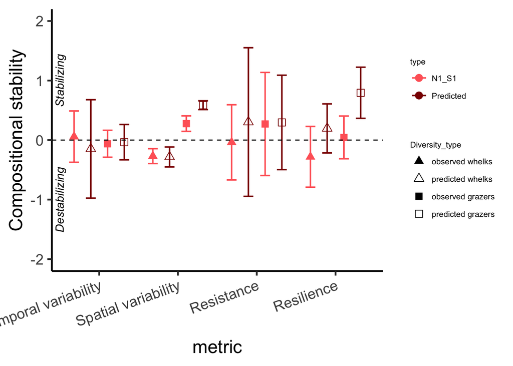

```r
contributions_Comp <- contributions_Comp%>%
  separate(Treatment, c("Diversity", "Nutrients","Sediment"))%>%
  unite(Disturbance,c("Nutrients","Sediment"),sep="_")%>%
  filter(Disturbance != 'N0_S0')

predict_Comp<-lapply(contributions_Comp$metric %>% unique,function(i){
  y = contributions_Comp %>%
     filter(metric == i & Disturbance == "N0_S1" & Diversity == "A") %>% nrow
  lapply(c("A","B"), function(k){
    lapply(c("N0_S1","N1_S0"),function(j){
      x = contributions_Comp %>%
       filter(metric == i & Disturbance == j & Diversity == k)
      x$LRR_metric[sample(1:nrow(x),1000,replace = T)]
    }) %>%
      Reduce("+",.) %>%
      data_frame(type = "Predicted", Diversity = k, metric = i, LRR_metric = . ,n=y)
  })  %>% Reduce("rbind",.)
}) %>% Reduce("rbind",.)

contributions_Comp<-contributions_Comp%>%
  group_by(metric, Diversity, Disturbance)%>%
  summarise(n = n())%>%
  left_join(contributions_Comp,.)%>%
  rename(type = Disturbance)

predict_Comp<-rbind(as_data_frame(contributions_Comp %>%
  filter(type == "N1_S1")%>%
  select (type, Diversity, metric, LRR_metric, n)), predict_Comp)

predict_summary_Comp<-predict_Comp %>%
  group_by(type, Diversity, metric)%>%
  summarise(mean=mean(LRR_metric),  sd = sd(LRR_metric), n = unique(n))%>%
mutate(se = sd/sqrt(n),lower.ci = mean - qt(1 - (0.05 / 2), n - 1) * se, upper.ci = mean + qt(1 - (0.05 / 2), n - 1) * se)%>%
  ungroup(type, Diversity,metric) %>%
  unite("Diversity_type", Diversity, type, remove = FALSE)%>%
  mutate(metric = factor(metric,levels = c( "Temp.Var", "Spa.Var", "Resist", "Resilience")))%>%
  mutate(Diversity_type = factor(Diversity_type,levels = c( "B_N1_S1", "B_Predicted", "A_N1_S1", "A_Predicted")))%>%
  mutate(Diversity_type = plyr::mapvalues(Diversity_type, from = c("B_N1_S1", "B_Predicted", "A_N1_S1", "A_Predicted"), to = c("observed whelks","predicted whelks","observed grazers","predicted grazers")))%>%
  mutate(metric = plyr::mapvalues(metric, from = c("Temp.Var", "Spa.Var", "Resist", "Resilience"), to = c("Temporal variability", "Spatial variability", "Resistance", "Resilience")))%>%
  mutate(metric = factor(metric,levels = c( "Temporal variability", "Spatial variability", "Resistance", "Resilience")))


pred_Comp<-ggplot(predict_summary_Comp, aes(x=metric, y=mean, Diversity_type)) +
  geom_errorbar(aes(shape = Diversity_type, colour = type, ymin=lower.ci, ymax=upper.ci),      position=position_dodge(0.85), width = 0.5, size = 0.7) +
  geom_point(aes(shape = Diversity_type,colour = type),position=position_dodge(0.85), size = 3)+
  ylab("Compositional stability") +
  ylim(-2,2)+
  geom_hline(yintercept = 0, linetype="dashed") +
  theme_classic(base_size = 18)+
  theme(axis.text.x=element_text(angle=20,hjust=1), legend.text = element_text(size=8),legend.title = element_text(size=8)) +
  annotate("text", x = 0.5, y = -1, label="Destabilizing", color = "black",size = 4, angle=90,fontface = "italic")+
  annotate("text", x = 0.5, y = 1, label="Stabilizing", color = "black",size = 4, angle=90,fontface = "italic")+  scale_shape_manual(values=c( 17,2,15,0))+ scale_colour_manual(values = c("#FF6666", "dark red"))


pred_Full <- ggarrange(pred_Func + rremove("xlab") + rremove("x.text"), pred_Comp+ rremove("xlab"), heights = c(1,1), ncol = 1, nrow = 2,common.legend = T, labels = c("a", "b"))

pred_Comp
```

can do 2 tailed t-test for predicted vs observed, for grazer contribution to spa var. will check for equal variance first (is equal) so continue with standard 2 sample t test. also check that both are different from zero…

```r
var.test(filter(predict_Comp, metric == "Spa.Var" & Diversity == "B", type == "N1_S1")$LRR_metric, filter(predict, metric == "Spa.Var" & Diversity == "B", type == "Predicted")$LRR_metric)
```

```
##
##  F test to compare two variances
##
## data:  filter(predict_Comp, metric == "Spa.Var" & Diversity == "B", type == "N1_S1")$LRR_metric and filter(predict, metric == "Spa.Var" & Diversity == "B", type == "Predicted")$LRR_metric
## F = 0.22709, num df = 6, denom df = 999, p-value = 0.06402
## alternative hypothesis: true ratio of variances is not equal to 1
## 95 percent confidence interval:
##  0.09380658 1.10271336
## sample estimates:
## ratio of variances
##          0.2270923
```

```r
pp<-predict_Comp %>%
  filter(metric == "Spa.Var" & Diversity == "A")%>%
  t_test(LRR_metric ~ type)

p.adjust(pp$p, n = 2)
```

```
## [1] 0.00226
```

```r
# predict_Comp %>%
#  filter(metric == "Spa.Var" & Diversity == "B", type == "Predicted")%>%
#  t_test(LRR_metric ~ 1, mu = 0)

#predict_Comp %>%
#  filter(metric == "Spa.Var" & Diversity == "A")%>%
#  group_by(type) %>%
#  summarise (t_test(LRR_metric ~ 1, mu = 0))

test5 <- predict_Comp %>%
  filter(metric == "Spa.Var", Diversity== "A")%>%
  group_by(type) %>%
  summarise(pval = t.test(x = LRR_metric, mu = 0)$p.value,
            tval = t.test(x = LRR_metric, mu = 0)$statistic,
            conf = t.test(x = LRR_metric, mu = 0)$conf.int)

p.adjust(test5$pval, n = 4)
```

```
## [1] 0.004079892 0.004079892 0.000000000 0.000000000
```

```r
predict_Comp %>%
  group_by(metric, Diversity) %>%
  t_test(LRR_metric ~ type)
```

```
## # A tibble: 8 × 10
##   Diversity metric     .y.     group1 group2    n1    n2 statistic    df       p
## * <chr>     <chr>      <chr>   <chr>  <chr>  <int> <int>     <dbl> <dbl>   <dbl>
## 1 A         Resilience LRR_me… N1_S1  Predi…     5  1000   -5.78    4.06 0.00427
## 2 B         Resilience LRR_me… N1_S1  Predi…     5  1000   -2.59    4.03 0.0602
## 3 A         Resist     LRR_me… N1_S1  Predi…     5  1000   -0.0835  4.03 0.937
## 4 B         Resist     LRR_me… N1_S1  Predi…     5  1000   -1.48    4.16 0.209
## 5 A         Spa.Var    LRR_me… N1_S1  Predi…     7  1000   -5.80    6.03 0.00113
## 6 B         Spa.Var    LRR_me… N1_S1  Predi…     7  1000    0.271   6.15 0.795
## 7 A         Temp.Var   LRR_me… N1_S1  Predi…     5  1000   -0.331   4.07 0.757
## 8 B         Temp.Var   LRR_me… N1_S1  Predi…     5  1000    1.32    4.15 0.255
```